# A3 - Modelización predictiva

Yésica Fernández Ramos

2022-05-13

Antes de empezar con la práctica, vamos a cargar los paquetes necesarios para la realización del ejercicio.

```r
# https://cran.r-project.org/web/packages/dplyr/index.html
if (!require('dplyr')) install.packages('dplyr'); library('dplyr')
# https://cran.r-project.org/web/packages/ggplot2/index.html
if (!require('ggplot2')) install.packages('ggplot2'); library('ggplot2')
# https://cran.r-project.org/web/packages/graphics/index.html
if (!require('graphics')) install.packages('graphics'); library('graphics')
# https://cran.r-project.org/web/packages/ResourceSelection/index.html
if (!require('ResourceSelection')) install.packages('ResourceSelection'); library('ResourceSelection')
# https://cran.r-project.org/web/packages/ROCR/index.html
if (!require('ROCR')) install.packages('ROCR'); library('ROCR')
```

# Introducción

En esta actividad se usará el fichero de datos (dat_Air_Stations) que contiene información de diferentes parámetros sobre la calidad del aire de una determinada ciudad del Norte de España en el año 2018. Los datos nos muestran concentraciones por hora de varios contaminantes atmosféricos (gases y partículas) como SO2, NO2, O3 y PM10, entre otros, monitoreados en cinco estaciones. Por otro lado en dos de las cinco estaciones, se han recogido medidas de variables meteorológicas. El periodo que abarca este estudio está comprendido entre el 1 de Enero 2018 al 31 de Diciembre de 2018. Estos datos han sido medidos en tiempo real.

La contaminación del aire representa un importante riesgo medioambiental y para la salud, tanto en los países desarrollados como en los países en desarrollo, por lo que su estudio es muy necesario. Las variables del fichero de datos son:

- Estación: Estación móvil.
- Nombre: Nombre de la estación móvil.
- latitud: Latitud del lugar de medición.
- longitud: Longitud del lugar de medición.
- Fecha: Fecha de medición.
- Periodo: Mediciones cada hora. Periodo de 1 a 24 horas (diarias).
- SO2: Concentración de SO2 (dióxido de azufre) en μg/m3.
- NO: Concentración de NO (óxido nítrico) en μg/m3.
- NO2: Concentración de (dióxido de nitrógeno) en μg/m3.
- CO: Concentración de CO en μg/m3.
- O3: Concentración de Ozono en μg/m3.
- PM10: Partículas en suspensión <10 en μg/m3.
- PM25: Partículas en suspensión PM 2,5 en μg/m3.
- BEN: Concentración de benceno en μg/m3.
- TOL: Tolueno en μg/m3.
- MXIL: MiXileno en μg/m3.
- dd: Dirección del viento en grados.
- vv: Velocidad del viento en m/sg.
- TMP: Temperatura en grados centígrados.
- HR: Humedad relativa en % de hr.
- PRB: Presión Atmosférica en mb.
- RS: Radiación Solar en W/m2.
- LL: Precipitación en l/m2.

# Carga de los datos

En primer lugar, se realiza la carga del fichero y se observa que se ha realizado correctamente.

```r
AirStations <- read.csv("dat_Air_Stations.csv", sep = ",")
AirStations$Fecha <- as.Date(AirStations$Fecha, format = "%d/%m/%Y")
summary(AirStations)
```

```
##     Estacion     Nombre             latitud         longitud
##  Min.   : 1   Length:43799       Min.   :43.52   Min.   :-5.699
##  1st Qu.: 2   Class :character   1st Qu.:43.53   1st Qu.:-5.673
##  Median : 3   Mode  :character   Median :43.54   Median :-5.672
##  Mean   : 4                      Mean   :43.53   Mean   :-5.670
##  3rd Qu.: 4                      3rd Qu.:43.54   3rd Qu.:-5.658
##  Max.   :10                      Max.   :43.54   Max.   :-5.646
##
##      Fecha               Periodo          SO2               NO
##  Min.   :2018-01-01   Min.   : 1.0   Min.   : 1.000   Min.   :  1.00
##  1st Qu.:2018-04-02   1st Qu.: 7.0   1st Qu.: 3.000   1st Qu.:  2.00
##  Median :2018-07-02   Median :13.0   Median : 5.000   Median :  5.00
##  Mean   :2018-07-02   Mean   :12.5   Mean   : 5.701   Mean   : 13.04
##  3rd Qu.:2018-10-01   3rd Qu.:18.5   3rd Qu.: 7.000   3rd Qu.: 11.00
##  Max.   :2018-12-31   Max.   :24.0   Max.   :90.000   Max.   :394.00
##                                      NA's   :598      NA's   :332
##       NO2               CO             PM10              O3
##  Min.   :  1.00   Min.   :0.100   Min.   :  0.00   Min.   :  1.00
##  1st Qu.: 12.00   1st Qu.:0.190   1st Qu.: 14.90   1st Qu.: 24.00
##  Median : 20.00   Median :0.300   Median : 22.30   Median : 49.00
##  Mean   : 24.49   Mean   :0.396   Mean   : 25.24   Mean   : 47.24
##  3rd Qu.: 33.00   3rd Qu.:0.470   3rd Qu.: 30.80   3rd Qu.: 68.00
##  Max.   :130.00   Max.   :9.510   Max.   :395.00   Max.   :134.00
##  NA's   :349      NA's   :9075    NA's   :546      NA's   :652
##        dd              vv              TMP              HR
##  Min.   :  0.0   Min.   : 0.000   Min.   :-1.60   Min.   : 25.0
##  1st Qu.:135.0   1st Qu.: 0.170   1st Qu.:10.80   1st Qu.: 68.0
##  Median :197.0   Median : 0.640   Median :14.90   Median : 80.0
##  Mean   :202.1   Mean   : 0.949   Mean   :14.92   Mean   : 78.2
##  3rd Qu.:295.0   3rd Qu.: 1.350   3rd Qu.:19.00   3rd Qu.: 90.0
##  Max.   :360.0   Max.   :11.800   Max.   :30.90   Max.   :100.0
##  NA's   :26617   NA's   :26617    NA's   :26389   NA's   :26389
##       PRB              RS              LL             BEN
##  Min.   : 969    Min.   :  2.0   Min.   : 0.00   Min.   :0.12
##  1st Qu.:1010    1st Qu.:  4.0   1st Qu.: 0.00   1st Qu.:0.24
##  Median :1015    Median : 54.0   Median : 0.00   Median :0.39
##  Mean   :1014    Mean   :110.6   Mean   : 0.12   Mean   :0.58
##  3rd Qu.:1020    3rd Qu.:110.0   3rd Qu.: 0.00   3rd Qu.:0.66
##  Max.   :1038    Max.   :841.0   Max.   :19.00   Max.   :9.53
##  NA's   :26389   NA's   :26389   NA's   :26389   NA's   :35224
##       TOL              MXIL             PM25
##  Min.   :  0.03   Min.   :  0.03   Min.   : 1.00
##  1st Qu.:  0.64   1st Qu.:  0.27   1st Qu.: 5.00
##  Median :  1.37   Median :  0.82   Median : 9.00
##  Mean   :  2.83   Mean   :  2.28   Mean   :10.29
##  3rd Qu.:  3.02   3rd Qu.:  2.29   3rd Qu.:14.00
##  Max.   :182.00   Max.   :134.00   Max.   :96.00
##  NA's   :35224    NA's   :35559    NA's   :26502
```

# 1.- Regresión Lineal

*La exposición a la materia particulada (PM10), al ozono (O3), al dióxido de nitrógeno (NO2) y el dióxido de azufre (SO2), plantean graves riesgos para la salud. Las directrices de la OMS sobre la calidad del aire establecen los límites sobre estos principales contaminantes atmosféricos.

PM10: Límite de 45 microgramos de partículas por cada metro cúbico μg/m3. SO2: Límite de 40 μg/m3. NO2: Límite de 25 μg/m3. O3: Límite de 60 μg/m3.

El índice de calidad del aire se calcula de forma individual teniendo en cuenta cada uno de dichos contaminantes. Todos estos valores están referidos a la media diaria.

Con referencia a valores máximos diarios se tomarán los valores de 100 μg/m3 para O3 y de 120 μg/m3 para NO2. Tanto para PM10 y SO2, se tomarán como referencia únicamente los valores medios diarios para comparar.*

## 1.1- Estudio comparativo entre estaciones

### a) Estudio de los valores medios y máximos diarios de cada contaminante

*Para cada una de las estaciones de monitoreo, se calcularán los valores máximos y medios diarios de cada contaminante. Posteriormente se hará una comparativa entre las cinco estaciones en base a dichos valores. Interpretad teniendo en cuenta los límites mencionados anteriormente.*

En primer lugar, vamos a calcular los valores medios diarios de cada contaminante.

```r
AirStationsMediasPM10 <- aggregate(PM10~Fecha + Nombre, AirStations, mean, na.rm=TRUE)
AirStationsMediasO3 <- aggregate(O3~Fecha + Nombre, AirStations, mean, na.rm=TRUE)
AirStationsMediasNO2 <- aggregate(NO2~Fecha + Nombre, AirStations, mean, na.rm=TRUE)
AirStationsMediasSO2 <- aggregate(SO2~Fecha + Nombre, AirStations, mean, na.rm=TRUE)
AirStationMedias <- merge( x = merge( x = merge(x = AirStationsMediasPM10, y = AirStationsMediasO3), y = AirStationsMediasNO2), y =AirStationsMediasSO2)

head(AirStationMedias)
```

```
##        Fecha                               Nombre     PM10       O3       NO2
## 1 2018-01-01           Estacion Avenida Argentina 26.06667 57.29167 16.500000
## 2 2018-01-01            Estacion Avenida Castilla 15.25583 69.75000 12.166667
## 3 2018-01-01        Estacion Avenida Constitucion 13.80208 58.83333 21.000000
## 4 2018-01-01 Estacion Avenida Hermanos Felgueroso 14.29500 62.91667 18.583333
## 5 2018-01-01                 Estacion de Montevil 18.41125 69.83333  9.583333
## 6 2018-01-02           Estacion Avenida Argentina 30.23583 45.16667 22.666667
##         SO2
## 1 13.625000
## 2  4.666667
## 3  4.250000
## 4  2.166667
## 5  4.416667
## 6 17.875000
```

Vamos a comparar las medias diarias en base a los límites.

```r
filter(AirStationMedias, PM10 > 45) %>% count(Nombre)
```

```
##                                 Nombre  n
## 1           Estacion Avenida Argentina 29
## 2            Estacion Avenida Castilla 21
## 3 Estacion Avenida Hermanos Felgueroso 18
## 4                 Estacion de Montevil 10
```

Se observa que la estación de Montevil los límites del PM10 10 días.

```r
filter(AirStationMedias, SO2 > 40) %>% count(Nombre)
```

```
## [1] Nombre n
## <0 rows> (or 0-length row.names)
```

No sé ven evidencias de que se superen los límites de SO2 en las estaciones.

```r
filter(AirStationMedias, NO2 > 25) %>% count(Nombre)
```

```
##                                 Nombre   n
## 1           Estacion Avenida Argentina 159
## 2            Estacion Avenida Castilla  84
## 3        Estacion Avenida Constitucion 201
## 4 Estacion Avenida Hermanos Felgueroso 221
## 5                 Estacion de Montevil  92
```

Se observa que la estación Avenida Constitución supera los límites más de la mitad del año. La de Estación de Montevil también los supera 92 días.

```r
filter(AirStationMedias, O3 > 60) %>% count(Nombre)
```

```
##                                 Nombre   n
## 1           Estacion Avenida Argentina  84
## 2            Estacion Avenida Castilla 124
## 3        Estacion Avenida Constitucion  66
## 4 Estacion Avenida Hermanos Felgueroso  87
## 5                 Estacion de Montevil 110
```

Por último, vemos que la estación Avenida da Constitución supera los límites de O3 66 días y la Estación de Montevil los supera 110 días.

Ahora se calculan los máximos de los contaminantes.

```r
AirStationsMaximosPM10 <- aggregate(PM10~Fecha + Nombre, AirStations, max, na.rm=TRUE)
AirStationsMaximosO3 <- aggregate(O3~Fecha + Nombre, AirStations, max, na.rm=TRUE)
AirStationsMaximosNO2 <- aggregate(NO2~Fecha + Nombre, AirStations, max, na.rm=TRUE)
AirStationsMaximosSO2 <- aggregate(SO2~Fecha + Nombre, AirStations, max, na.rm=TRUE)
AirStationMaximos <- merge( x = merge( x = merge(x = AirStationsMaximosPM10, y = AirStationsMaximosO3), y = AirStationsMaximosNO2), y =AirStationsMaximosSO2)

head(AirStationMaximos)
```

```
##        Fecha                               Nombre PM10 O3 NO2 SO2
## 1 2018-01-01           Estacion Avenida Argentina 48.9 70  33  28
## 2 2018-01-01            Estacion Avenida Castilla 36.1 95  35   6
## 3 2018-01-01        Estacion Avenida Constitucion 29.7 80  55  11
## 4 2018-01-01 Estacion Avenida Hermanos Felgueroso 29.7 83  52   3
## 5 2018-01-01                 Estacion de Montevil 26.6 83  38   9
## 6 2018-01-02           Estacion Avenida Argentina 52.0 66  40  53
```

Vamos a realizar la comparativa con los valores máximos diarios.

```r
filter(AirStationMaximos, O3 > 100) %>% count(Nombre)
```

```
##                                 Nombre  n
## 1           Estacion Avenida Argentina 21
## 2            Estacion Avenida Castilla 46
## 3        Estacion Avenida Constitucion 21
## 4 Estacion Avenida Hermanos Felgueroso 21
## 5                 Estacion de Montevil 40
```

En este caso las cinco estaciones superan los máximos diarios de O3, se observan arriba el número de días.

```r
filter(AirStationMaximos, NO2 > 120) %>% count(Nombre)
```

```
##                          Nombre n
## 1    Estacion Avenida Argentina 1
## 2 Estacion Avenida Constitucion 1
```

En este caso sólo se superan los máximos diarios en dos estaciones, y sólo un día para cada una.

### b) Representación gráfica

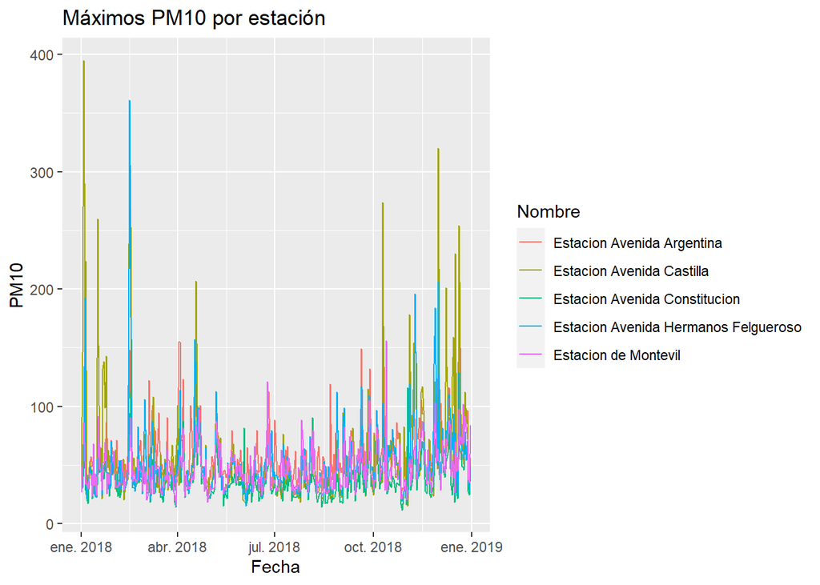

```r
ggplot(AirStationsMaximosPM10, aes(x = Fecha, y = PM10, group = Nombre)) +
  geom_line(aes(color = Nombre))+
  ggtitle("Máximos PM10 por estación")
```

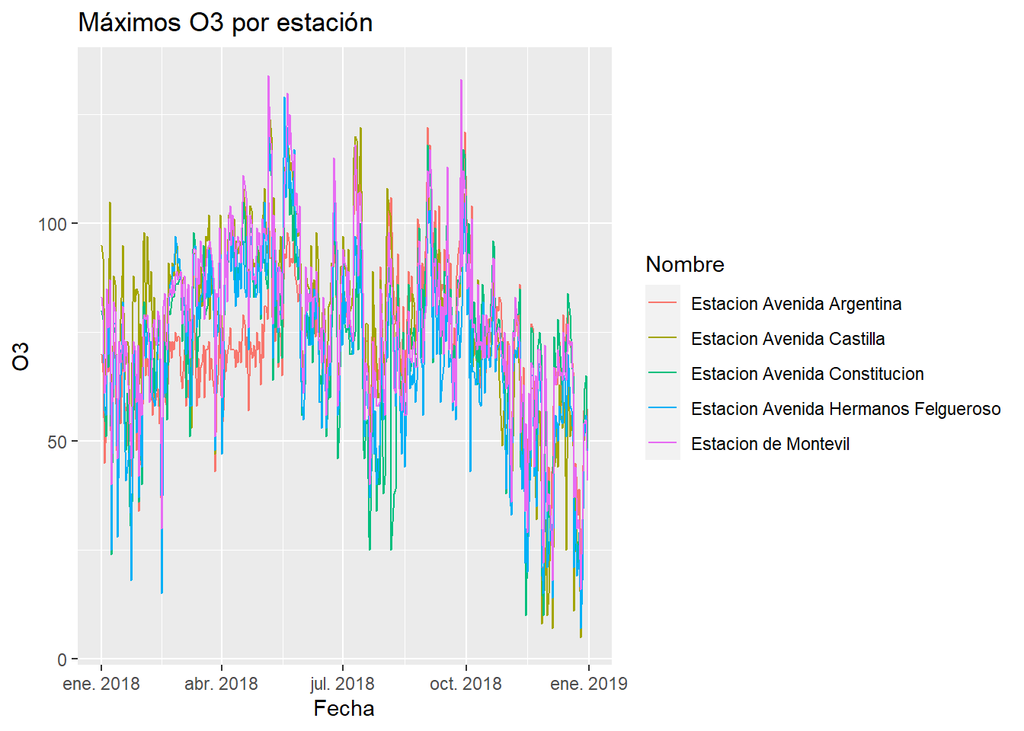

```r
ggplot(AirStationsMaximosO3, aes(x = Fecha, y = O3, group = Nombre)) +
  geom_line(aes(color = Nombre))+
  ggtitle("Máximos O3 por estación")
```

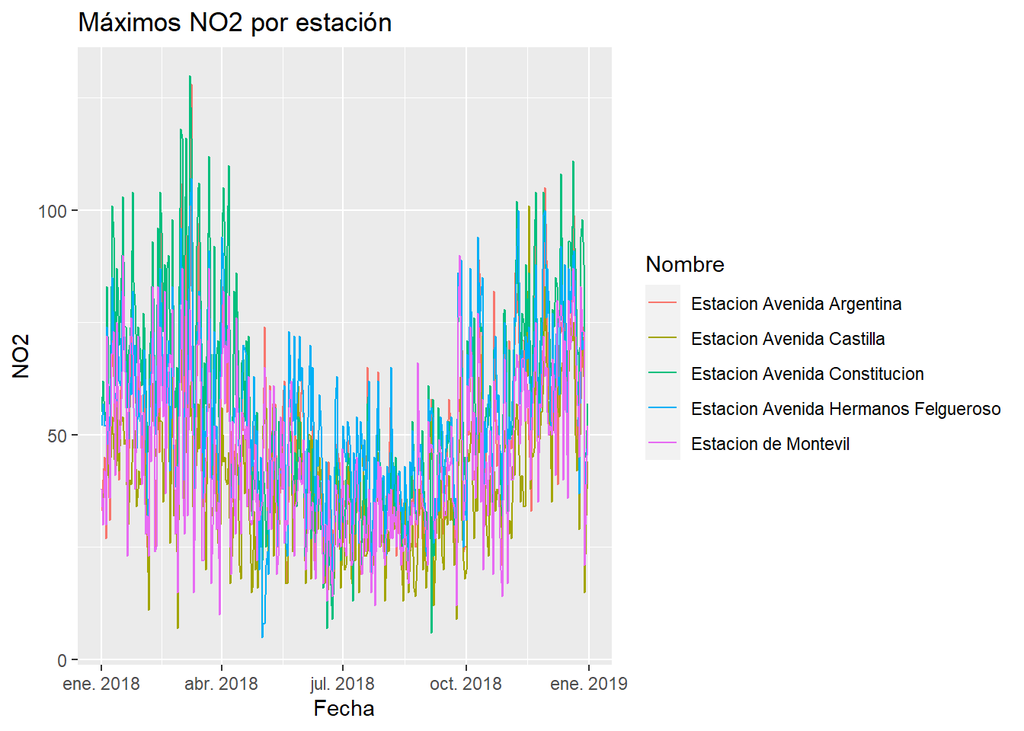

```r
ggplot(AirStationsMaximosNO2, aes(x = Fecha, y = NO2, group = Nombre)) +
  geom_line(aes(color = Nombre))+
  ggtitle("Máximos NO2 por estación")
```

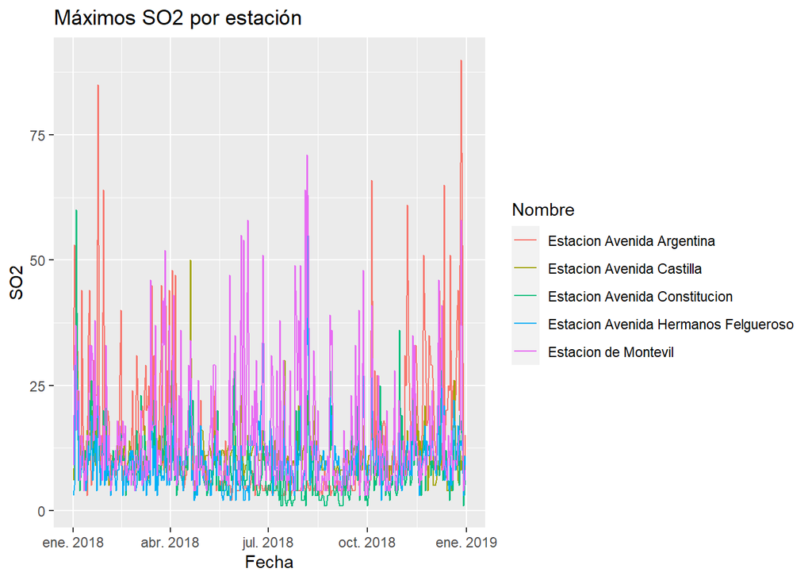

```r
ggplot(AirStationsMaximosSO2, aes(x = Fecha, y = SO2, group = Nombre)) +
  geom_line(aes(color = Nombre))+
  ggtitle("Máximos SO2 por estación")
```

### c) Estudio de correlación lineal

*Para ello se seleccionan las dos estaciones con registros meteorológicos: Estación de Montevil y Estación Avenida Constitución. Para cada una de las estaciones, calcular la matriz de correlación entre los contaminantes citados anteriormente y las variables meteorológicas: Temperatura (TMP), Humedad Relativa (HR), Radiación solar (RS), velocidad del viento (vv), precipitaciones (LL) y Presión barométrica (PRB).Interpretad.*

Para calcular la matriz de correlacion, tenemos que calcular las medias también de las variables meteorológicas, para contar con el mismo número de variables.

```r
AirStationsMediasTMP <- aggregate(TMP~Fecha + Nombre, AirStations, mean, na.rm=TRUE)
AirStationsMediasHR <- aggregate(HR~Fecha + Nombre, AirStations, mean, na.rm=TRUE)
AirStationsMediasRS <- aggregate(RS~Fecha + Nombre, AirStations, mean, na.rm=TRUE)
AirStationsMediasvv<- aggregate(vv~Fecha + Nombre, AirStations, mean, na.rm=TRUE)
AirStationsMediasLL <- aggregate(LL~Fecha + Nombre, AirStations, mean, na.rm=TRUE)
AirStationsMediasPRB <- aggregate(PRB~Fecha + Nombre, AirStations, mean, na.rm=TRUE)
AirStationMedias <- merge( x =merge( x=merge( x=merge( x = merge( x = merge(x = AirStationMedias, y = AirStationsMediasTMP), y = AirStationsMediasHR), y =AirStationsMediasRS), y= AirStationsMediasvv), y=AirStationsMediasLL), y=AirStationsMediasPRB)

head(AirStationMedias)
```

```
##        Fecha                        Nombre     PM10       O3       NO2
## 1 2018-01-01 Estacion Avenida Constitucion 13.80208 58.83333 21.000000
## 2 2018-01-01          Estacion de Montevil 18.41125 69.83333  9.583333
## 3 2018-01-02 Estacion Avenida Constitucion 12.78750 50.70833 23.291667
## 4 2018-01-02          Estacion de Montevil 13.88833 63.29167  9.916667
## 5 2018-01-03 Estacion Avenida Constitucion 20.31500 31.00000 29.916667
## 6 2018-01-03          Estacion de Montevil 24.64750 42.54167 17.375000
##         SO2      TMP       HR        RS       vv        LL      PRB
## 1  4.250000 13.65833 60.00000 101.08333 1.345000 0.3583333 1022.917
## 2  4.416667 14.71250 68.91667  76.95833 4.310000 0.3083333 1020.042
## 3  4.750000 18.25833 56.41667  89.70833 1.029583 0.0000000 1023.250
## 4  5.291667 19.30417 62.41667  61.79167 3.611250 0.0000000 1020.667
## 5  9.166667 18.95833 61.66667  98.91667 0.615000 0.0000000 1024.250
## 6 11.166667 19.94583 69.41667  74.29167 3.097500 0.0000000 1021.542
```

Ahora ya podemos calcular la matriz de correlacción.

```r
round(cor(AirStationMedias[, !(names(AirStationMedias) %in% c("Fecha", "Nombre"))], use = "complete.obs"), 2)
```

```
##       PM10    O3   NO2   SO2   TMP    HR    RS    vv    LL   PRB
## PM10  1.00 -0.14  0.22  0.43  0.12  0.24 -0.17 -0.03 -0.28  0.17
## O3   -0.14  1.00 -0.64 -0.16  0.12  0.04  0.31  0.47  0.12 -0.20
## NO2   0.22 -0.64  1.00  0.19 -0.44 -0.40 -0.12 -0.48 -0.10  0.02
## SO2   0.43 -0.16  0.19  1.00 -0.10  0.03 -0.26  0.23  0.00 -0.06
## TMP   0.12  0.12 -0.44 -0.10  1.00  0.30  0.06 -0.01 -0.21  0.14
## HR    0.24  0.04 -0.40  0.03  0.30  1.00 -0.30  0.05  0.25  0.12
## RS   -0.17  0.31 -0.12 -0.26  0.06 -0.30  1.00 -0.19 -0.17  0.07
## vv   -0.03  0.47 -0.48  0.23 -0.01  0.05 -0.19  1.00  0.11 -0.26
## LL   -0.28  0.12 -0.10  0.00 -0.21  0.25 -0.17  0.11  1.00 -0.20
## PRB   0.17 -0.20  0.02 -0.06  0.14  0.12  0.07 -0.26 -0.20  1.00
```

Por último, el contaminante SO2 no tiene valores de correlacion lo suficientemente elevados para tenerlos en cuenta.

## 1.2.- Modelo de regresión lineal

*Como he mencionado arriba, para construir los modelos de regresión, se tomarán los valores de las variables escogidas por hora, tal como aparecen en la base de datos original.*

### a) Crear modelo de regresión lineal

*Se pide crear un modelo de regresión lineal, tomando como variable dependiente (O3) y variable explicativa (NO2). Se evaluará la bondad del ajuste, a partir del coeficiente de determinación. Interpretad.*

```r
regresion <- lm(O3~NO2, data =AirStations)
summary(regresion)
```

```
##
## Call:
## lm(formula = O3 ~ NO2, data = AirStations)
##
## Residuals:
##     Min      1Q  Median      3Q     Max
## -63.353 -13.910   0.828  13.868  85.682
##
## Coefficients:
##              Estimate Std. Error t value Pr(>|t|)
## (Intercept) 72.649230   0.174380   416.6   <2e-16 ***
## NO2         -1.036976   0.005861  -176.9   <2e-16 ***
## ---
## Signif. codes:  0 '***' 0.001 '**' 0.01 '*' 0.05 '.' 0.1 ' ' 1
##
## Residual standard error: 20.53 on 43118 degrees of freedom
##   (679 observations deleted due to missingness)
## Multiple R-squared:  0.4207, Adjusted R-squared:  0.4206
## F-statistic: 3.131e+04 on 1 and 43118 DF,  p-value: < 2.2e-16
```

Los parámetros de la ecuación de la recta de mínimos cuadrados que relaciona la cantidad de O3 en función de la cantidad de NO2 vienen dados por la columna “Estimate” de la tabla “Coefficients” de la salida anterior. Por lo tanto, la ecuación sería:

$$

y = 72.64 - 1.03x

$$

El coeficiente de determinación (es decir, el coeficiente de correlación al cuadrado) mide la bondad del ajuste de la recta a los datos. Como se ve en la salida anterior, el coeficiente es: 0.4207. Por lo tanto, sólo un 42% de los datos quedan explicados con este modelo de regresión. El ajuste es bajo.

La recta de regresión lineal es la siguiente:

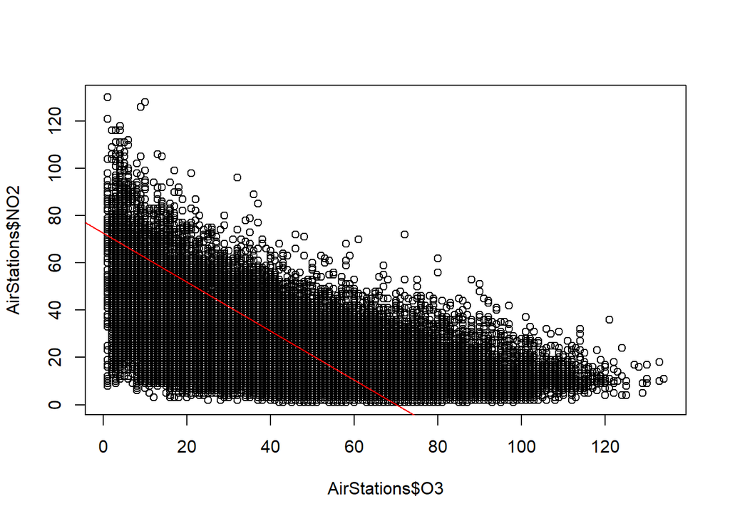

```r
plot(AirStations$O3, AirStations$NO2)
abline(regresion, col = "red")
```

### b) Se añade al modelo anterior el nombre de las estaciones (Nombre). Interpretad.

Se genera el modelo.

```r
regresion2 <- lm(O3 ~ NO2 + Nombre, data = AirStations)
summary(regresion2)
```

```
##
## Call:
## lm(formula = O3 ~ NO2 + Nombre, data = AirStations)
##
## Residuals:
##     Min      1Q  Median      3Q     Max
## -60.684 -13.871   0.679  13.893  85.154
##
## Coefficients:
##                                             Estimate Std. Error  t value
## (Intercept)                                75.305599   0.266607  282.459
## NO2                                        -1.065195   0.006029 -176.693
## NombreEstacion Avenida Castilla            -5.100212   0.312240  -16.334
## NombreEstacion Avenida Constitucion        -1.112099   0.312823   -3.555
## NombreEstacion Avenida Hermanos Felgueroso  0.231370   0.311964    0.742
## NombreEstacion de Montevil                 -3.788765   0.311481  -12.164
##                                            Pr(>|t|)
## (Intercept)                                 < 2e-16 ***
## NO2                                         < 2e-16 ***
## NombreEstacion Avenida Castilla             < 2e-16 ***
## NombreEstacion Avenida Constitucion        0.000378 ***
## NombreEstacion Avenida Hermanos Felgueroso 0.458300
## NombreEstacion de Montevil                  < 2e-16 ***
## ---
## Signif. codes:  0 '***' 0.001 '**' 0.01 '*' 0.05 '.' 0.1 ' ' 1
##
## Residual standard error: 20.42 on 43114 degrees of freedom
##   (679 observations deleted due to missingness)
## Multiple R-squared:  0.4266, Adjusted R-squared:  0.4265
## F-statistic:  6415 on 5 and 43114 DF,  p-value: < 2.2e-16
```

En este caso, el coeficiente de determinación es de 0.4266, lo que indica que solo un 42% de los datos se explican con el modelo creado. Por lo el modelo no mejora con respecto al anterior añadiendo la varibale explicativa “nombre”.

## 1.3.- Modelo de regresión lineal múltiple

*Se quiere construir un modelo de regresión múltiple con el que podamos predecir la concentración de ozono (O3) en las zonas de Montevil y Avenida de la Constitución.*

### a)

*Se pide dos modelos (uno para cada estación) tomando como variable dependiente el nivel de ozono (O3) en función de la concentración de dióxido de nitrógeno (NO2) y diferentes variables meteorológicas como vv (velocidad del viento), RS (radiación solar), HR (humedad relativa) y LL (precipitaciones).*

En primer lugar, se separan los datos de las estaciones.

```r
EstacionMontevil <- filter(AirStations, Nombre == "Estacion de Montevil")
EstacionAvenidaConstitucion <- filter(AirStations, Nombre == "Estacion Avenida Constitucion")
```

Ahora, generamos los modelos para cada estación. Primero procedemos con la estación Montevil.

```r
modelo1 <- lm(O3~NO2 + vv + RS + LL , data = EstacionMontevil)
summary(modelo1)
```

```
##
## Call:
## lm(formula = O3 ~ NO2 + vv + RS + LL, data = EstacionMontevil)
##
## Residuals:
##     Min      1Q  Median      3Q     Max
## -53.139 -12.710  -0.581  11.380  80.529
##
## Coefficients:
##              Estimate Std. Error t value Pr(>|t|)
## (Intercept) 59.162674   0.491215 120.441   <2e-16 ***
## NO2         -1.047990   0.014195 -73.827   <2e-16 ***
## vv           6.332902   0.187163  33.836   <2e-16 ***
## RS           0.041715   0.001444  28.897   <2e-16 ***
## LL           1.402598   0.307075   4.568    5e-06 ***
## ---
## Signif. codes:  0 '***' 0.001 '**' 0.01 '*' 0.05 '.' 0.1 ' ' 1
##
## Residual standard error: 17.88 on 8662 degrees of freedom
##   (93 observations deleted due to missingness)
## Multiple R-squared:  0.5921, Adjusted R-squared:  0.5919
## F-statistic:  3144 on 4 and 8662 DF,  p-value: < 2.2e-16
```

Con todas las variables meteorológicas tenemos un modelo con un coeficiente de terminanción del 0.5921, lo que se acerca más a 1.

Vamos a crear ahora el modelo para la estación Avenida Constitución siguiendo los pasos anteriores.

```r
modelo2 <- lm(O3 ~ NO2 + vv + RS + LL, data = EstacionAvenidaConstitucion)
summary(modelo2)
```

```
##
## Call:
## lm(formula = O3 ~ NO2 + vv + RS + LL, data = EstacionAvenidaConstitucion)
##
## Residuals:
##     Min      1Q  Median      3Q     Max
## -84.814 -13.271  -0.092  12.254  72.926
##
## Coefficients:
##              Estimate Std. Error t value Pr(>|t|)
## (Intercept) 53.093443   0.492395 107.827  < 2e-16 ***
## NO2         -0.702250   0.010903 -64.406  < 2e-16 ***
## vv          19.123130   0.451328  42.371  < 2e-16 ***
## RS           0.011458   0.001403   8.165 3.68e-16 ***
## LL           1.553346   0.356028   4.363 1.30e-05 ***
## ---
## Signif. codes:  0 '***' 0.001 '**' 0.01 '*' 0.05 '.' 0.1 ' ' 1
##
## Residual standard error: 18.3 on 8277 degrees of freedom
##   (478 observations deleted due to missingness)
## Multiple R-squared:  0.5685, Adjusted R-squared:  0.5682
## F-statistic:  2726 on 4 and 8277 DF,  p-value: < 2.2e-16
```

En este caso el coeficiente de determinación del modelo es de 0.5685, lo que indica que el 56.85% de los datos quedan explicados con el modelo.

### b)

*Se añade a los modelos anteriores la variable Temperatura (TMP). De ser necesario, se pide comprobar la presencia o no de colinealidad entre las variables (vv) y (TMP). Podéis usar la librería (faraway) y estudiar el FIV (factor de inflación de la varianza). Discutid si sería indicado o no añadir la variable (TMP) a cada uno de los modelos.*

En primer lugar, vamor a observar la correlación de las variables.

```r
round(cor(EstacionMontevil[, c("vv", "TMP")],use = "complete.obs"), 2)
```

```
##       vv  TMP
## vv  1.00 0.05
## TMP 0.05 1.00
```

```r
round(cor(EstacionAvenidaConstitucion[, c("vv", "TMP")],use = "complete.obs"), 2)
```

```
##       vv  TMP
## vv  1.00 0.19
## TMP 0.19 1.00
```

Se observa en las matrices de correlaciones que las variables vv y TMP no son linealmente dependientes, por lo que no tenemos que preocuparnos de la colinealidad entre estos predictores. Vamos a añadir la temperatura a los modelos, primero al de la estación Montevil.

```r
modelo3 <- lm(O3~NO2 + vv + RS + LL + TMP , data = EstacionMontevil)
summary(modelo3)
```

```
##
## Call:
## lm(formula = O3 ~ NO2 + vv + RS + LL + TMP, data = EstacionMontevil)
##
## Residuals:
##     Min      1Q  Median      3Q     Max
## -53.371 -12.761  -0.408  11.538  75.866
##
## Coefficients:
##              Estimate Std. Error t value Pr(>|t|)
## (Intercept) 52.932030   0.832564  63.577  < 2e-16 ***
## NO2         -1.013102   0.014622 -69.287  < 2e-16 ***
## vv           6.450918   0.186694  34.553  < 2e-16 ***
## RS           0.040123   0.001447  27.731  < 2e-16 ***
## LL           1.725117   0.307573   5.609  2.1e-08 ***
## TMP          0.349427   0.037796   9.245  < 2e-16 ***
## ---
## Signif. codes:  0 '***' 0.001 '**' 0.01 '*' 0.05 '.' 0.1 ' ' 1
##
## Residual standard error: 17.8 on 8661 degrees of freedom
##   (93 observations deleted due to missingness)
## Multiple R-squared:  0.5961, Adjusted R-squared:  0.5959
## F-statistic:  2557 on 5 and 8661 DF,  p-value: < 2.2e-16
```

En este caso el coeficiente de detminación es de 0.5961, lo que indica que el 59.61% de los datos son explicados con este modelo. Esto es un 0.40% más que con el modelo sin la variable explicativa temperatura. Como mejora el modelo, sería indicado añadir la variable.

Vamos ahora a añadir la temperatura al modelo de la estación Avenida Constitución.

```r
modelo4 <- lm(O3~NO2 + vv + RS + LL + TMP , data = EstacionAvenidaConstitucion)
summary(modelo4)
```

```
##
## Call:
## lm(formula = O3 ~ NO2 + vv + RS + LL + TMP, data = EstacionAvenidaConstitucion)
##
## Residuals:
##     Min      1Q  Median      3Q     Max
## -84.450 -13.156  -0.083  12.190  73.615
##
## Coefficients:
##             Estimate Std. Error t value Pr(>|t|)
## (Intercept) 54.14894    0.82506  65.630  < 2e-16 ***
## NO2         -0.70721    0.01134 -62.376  < 2e-16 ***
## vv          19.06028    0.45300  42.075  < 2e-16 ***
## RS           0.01226    0.00149   8.225 2.24e-16 ***
## LL           1.50333    0.35737   4.207 2.62e-05 ***
## TMP         -0.07083    0.04443  -1.594    0.111
## ---
## Signif. codes:  0 '***' 0.001 '**' 0.01 '*' 0.05 '.' 0.1 ' ' 1
##
## Residual standard error: 18.3 on 8276 degrees of freedom
##   (478 observations deleted due to missingness)
## Multiple R-squared:  0.5686, Adjusted R-squared:  0.5683
## F-statistic:  2182 on 5 and 8276 DF,  p-value: < 2.2e-16
```

En este caso el coeficiente de determinación es de 0.5686, lo que indica que el 56.86% de los datos quedan explicados con el modelo. Si lo comparamos con el anterior, el porcentaje de mejora es de un 0.01%, lo cual es mínimo. Además, se observa en el resultado del modelo que la variable temperatura no es significativa. Por lo tanto, no la añadiría al modelo.

## 1.4. Diagnosis del modelo

*Para la diagnosis se escoge el último modelo construído para la estación de Montevil y se piden dos gráficos: uno con los valores ajustados frente a los residuos (que nos permitirá ver si la varianza es constante) y el gráfico cuantil-cuantil que compara los residuos del modelo con los valores de una variable que se distribuye normalmente(QQ plot). Interpretad los resultados.*

El último modelo construido para la estación de Montevil es el siguiente:

```r
modelo3 <- lm(O3~NO2 + vv + RS + LL + TMP , data = EstacionMontevil)
summary(modelo3)
```

```
##
## Call:
## lm(formula = O3 ~ NO2 + vv + RS + LL + TMP, data = EstacionMontevil)
##
## Residuals:
##     Min      1Q  Median      3Q     Max
## -53.371 -12.761  -0.408  11.538  75.866
##
## Coefficients:
##              Estimate Std. Error t value Pr(>|t|)
## (Intercept) 52.932030   0.832564  63.577  < 2e-16 ***
## NO2         -1.013102   0.014622 -69.287  < 2e-16 ***
## vv           6.450918   0.186694  34.553  < 2e-16 ***
## RS           0.040123   0.001447  27.731  < 2e-16 ***
## LL           1.725117   0.307573   5.609  2.1e-08 ***
## TMP          0.349427   0.037796   9.245  < 2e-16 ***
## ---
## Signif. codes:  0 '***' 0.001 '**' 0.01 '*' 0.05 '.' 0.1 ' ' 1
##
## Residual standard error: 17.8 on 8661 degrees of freedom
##   (93 observations deleted due to missingness)
## Multiple R-squared:  0.5961, Adjusted R-squared:  0.5959
## F-statistic:  2557 on 5 and 8661 DF,  p-value: < 2.2e-16
```

Vamos a realizar las gráficas solicitadas.

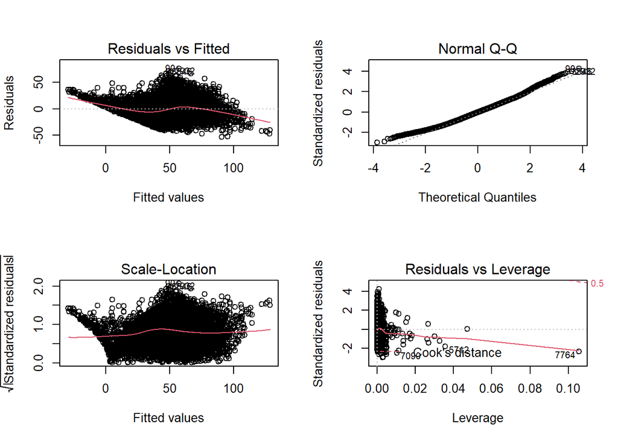

```r
par(mfrow = c(2,2))
plot(modelo3)
```

La gráfica de Q-Q es una gráfica de probabilidad normal. Dará una línea recta si los errores se distribuyen normalmente. En este caso se observa la línea recta, pero se desvía en los extremos.

## 1.5.- Predicción del modelo

*Según el modelo del apartado anterior, calculad la concentración de O3, si se tienen valores de NO2 de 40, vv de 2, RS de 100, HR de 80, LL de 0.10 y TMP de 25.*

```r
datos <- data.frame(NO2 = 40, vv = 2, RS = 100, HR = 80, LL = 0.10, TMP = 25)
p <- predict(modelo3, datos)
p
```

```
##        1
## 38.23027
```

Según el modelo, el valor de O3 sería 38.23.

# 2.- Regresión logística

*Para construir las nuevas variables y los modelos de regresión logística, se tomarán los valores de las variables escogidas por hora, tal como aparecen en la base de datos original. En este apartado se tomarán como contaminantes la concentración de PM10 y de O3. Se procederá a calcular los índices de calidad (icPM10 e icO3) de la forma siguiente:*

- PM10 recodificada: (icPM10)
  - **aceptable**: valores de (0 a 45],
  - **mejorable**: valores de (45 a 180]
- O3 recodificada: (ic03)
  - **aceptable**: valores de (0 a 60],
  - **mejorable**: valores de (60 a 170]

La variable RS también será recodificada:

- RS recodificada (RS_re):
  - **normal_baja**:(0 a 100],
  - **normal_alta**: valores de (100 a 700] Nota: Dicho índice de calidad se ha recodificado conforme a nuestros datos.

En primer lugar vamos a crear las variables anteriores.

```r
AirStations$icPM10 <- as.factor(ifelse(AirStations$PM10 > 0 & AirStations$PM10 <= 45.0,"aceptable", ifelse(AirStations$PM10 > 45.0 & AirStations$PM10 <= 180.0, "mejorable", NA)))
AirStations$icO3 <- as.factor(ifelse(AirStations$O3>0 & AirStations$O3 <=60, "aceptable", ifelse(AirStations$O3 > 60 & AirStations$O3 <= 170, "mejorable", NA)))
AirStations$RS_re <- as.factor(ifelse(AirStations$RS > 0 & AirStations$RS <= 100, "normal_baja", ifelse(AirStations$RS > 100 & AirStations$RS <=700, "normal_alta", NA)))
```

## 2.1.- Análisis crudo. Cálculo de OR

Se creará una nueva variable con los meses del año a partir de la variable Fecha, llamada month.

```r
AirStations$month <- as.numeric(format(AirStations$Fecha,'%m'))
```

### a) Cálculo OR

*Se calculará las OR (Odds-Ratio) entre cada una de las variables dependientes icPM10 y icO3 y las variables explicativas radiación solar recodificada (RS_re) y (month) en la estación de Montevil. Importante: Para el cálculo de las OR, se partirá de la tabla de contingencia y se calculará a partir de su fórmula. Debéis implementar dicha fórmula en R. ¿Se puede considerar que la radiación solar y el mes del año son factores de riesgo? Justifica tu respuesta e interpreta las OR.*

Para calcular el Oddstio (OR), que puede ser definido como una medida de asociación entre variables binarias se deben seguir los pados siguientes:

- En primer lugar, se realizará el estudio con varias funciones de las que extraeremos el computo final.
- Una OR = 1 quiere decir que no hay asociación entre las variables.
- Una OR < 1 quiere decir que el valor con el que se está comparando no es factor de riesgo.
- Una OR > 1 quiere decir que el valor con el que se está comparando es factor de riesgo.

Se implementan las funciones.

```r
oddsratioWald.proc <- function(n00, n01, n10, n11, alpha = 0.05){
  #
  #  Compute the odds ratio between two binary variables, x and y,
  #  as defined by the four numbers nij:
  #
  #    n00 = number of cases where x = 0 and y = 0
  #    n01 = number of cases where x = 0 and y = 1
  #    n10 = number of cases where x = 1 and y = 0
  #    n11 = number of cases where x = 1 and y = 1
  #
  OR <- (n00 * n11)/(n01 * n10)
  #
  #  Compute the Wald confidence intervals:
  #
  siglog <- sqrt((1/n00) + (1/n01) + (1/n10) + (1/n11))
  zalph <- qnorm(1 - alpha/2)
  logOR <- log(OR)
  loglo <- logOR - zalph * siglog
  loghi <- logOR + zalph * siglog
  #
  ORlo <- exp(loglo)
  ORhi <- exp(loghi)
  #
  oframe <- data.frame(LowerCI = ORlo, OR = OR, UpperCI = ORhi, alpha = alpha)
  oframe
}
AutomaticOR.proc <- function(x,y,alpha=0.05){
  #
  xtab <- table(x,y)
  n00 <- xtab[1,1]
  n01 <- xtab[1,2]
  n10 <- xtab[2,1]
  n11 <- xtab[2,2]
  #
  rawOR <- (n00*n11)/(n01*n10)
  if (rawOR < 1){
    n01 <- xtab[1,1]
    n00 <- xtab[1,2]
    n11 <- xtab[2,1]
    n10 <- xtab[2,2]
    iLevel <- 2
  }
  else{
    iLevel <- 1
  }
  outList <- vector("list",2)
  output <- oddsratioWald.proc(n00,n01,n10,n11,alpha)
  output
}
```

Separamos los datos de la estación de Montevil.

```r
EstacionMontevilLog <- filter(AirStations, Nombre == "Estacion de Montevil")
```

Ahora podemos llamar a la función y obtener el valor Odds para el primer estudio, la relación entre icPM10 y la variable explicativa RS_re.

Primero miramos la matriz de contingencia para la variable dependiente icPM10 y la variable explicativa RS_re.

```r
table(EstacionMontevilLog$icPM10, EstacionMontevilLog$RS_re)
```

```
##
##             normal_alta normal_baja
##   aceptable        1491        6506
##   mejorable          96         498
```

Calculamos el Odds.

```r
AutomaticOR.proc(EstacionMontevilLog$icPM10, EstacionMontevilLog$RS_re)
```

```
##     LowerCI       OR  UpperCI alpha
## 1 0.9487338 1.188835 1.489701  0.05
```

En el caso del mes, no se trata de una variable binaria, por lo que no podemos realizar el cálculo de OR. El cálculo del OR únicamente es válido para tablas de contingencia 2x2, varibales binarias. En este caso si podría estudiarse la relación entre el PM10 y dos meses en concreto o una categorización binaria de los meses ( por ejemplo, semestres).

Pasamos a mirar la matriz de contingencia para la variable dependiente icO3 y la variable explicativa RS_Re.

```r
table(EstacionMontevilLog$icO3, EstacionMontevilLog$RS_re)
```

```
##
##             normal_alta normal_baja
##   aceptable         463        4785
##   mejorable        1125        2229
```

Procedemos con el cálculo del Odds.

```r
AutomaticOR.proc(EstacionMontevilLog$icO3, EstacionMontevilLog$RS_re)
```

```
##    LowerCI      OR  UpperCI alpha
## 1 4.629377 5.21607 5.877116  0.05
```

En este caso se obtiene un Odds ratio de 5.21, lo que nos indica que la radiación solar es un factor de riesgo con respecto al O3.

Con el mes nos encontramos en el mismo caso anterior. Podemos hacer un ejemplo codificando el mes en una variable binaria: semestre 1 y semestre 2.

```r
EstacionMontevilLog$icMonth <- ifelse(EstacionMontevilLog$month <= 6, "semestre1", "semestre2")
```

Podemos calcular ahora el Odds ratio con esta nueva variable.

```r
AutomaticOR.proc(EstacionMontevilLog$icO3, EstacionMontevilLog$icMonth)
```

```
##    LowerCI      OR  UpperCI alpha
## 1 2.478308 2.70916 2.961516  0.05
```

El Odds ratio es 2.70 y como es superior a 1 podemos concluír que es factor de riesgo.

### b) Calculos OR para estación Avenida Constitución

Separamos los datos de la estación.

```r
EstacionAvenidaConstitucionLog <- filter(AirStations, Nombre == "Estacion Avenida Constitucion")
```

Pasamos a realizar los cálculos de los Odds ratio.

```r
AutomaticOR.proc(EstacionAvenidaConstitucionLog$icPM10, EstacionAvenidaConstitucionLog$RS_re)
```

```
##     LowerCI       OR  UpperCI alpha
## 1 0.9810104 1.302808 1.730164  0.05
```

```r
AutomaticOR.proc(EstacionAvenidaConstitucionLog$icO3, EstacionAvenidaConstitucionLog$RS_re)
```

```
##    LowerCI       OR  UpperCI alpha
## 1 2.253674 2.487093 2.744687  0.05
```

```r
EstacionAvenidaConstitucionLog$icMonth <- ifelse(EstacionAvenidaConstitucionLog$month <= 6, "semestre1", "semestre2")
AutomaticOR.proc(EstacionAvenidaConstitucionLog$icPM10, EstacionAvenidaConstitucionLog$icMonth)
```

```
##     LowerCI       OR  UpperCI alpha
## 1 0.8568771 1.101376 1.415639  0.05
```

```r
AutomaticOR.proc(EstacionAvenidaConstitucionLog$icO3, EstacionAvenidaConstitucionLog$icMonth)
```

```
##   LowerCI      OR  UpperCI alpha
## 1 1.80757 1.98708 2.184418  0.05
```

## 2.2.- Modelo de regresión logística

*Para la estación de Montevil del apartado anterior:*

### a) Modelo de regresión logística

*Se pide construir un modelo de regresión logística tomando como variable dependiente icPM10 y variables explicativas (RS_re), (vv) y (PRB). Interpretad y calculad las OR.*

Creamos el modelo de regresión logística.

```r
modelo5 <- glm(icPM10 ~ RS_re + vv + PRB, data = EstacionMontevilLog, family = "binomial" )
summary(modelo5)
```

```
##
## Call:
## glm(formula = icPM10 ~ RS_re + vv + PRB, family = "binomial",
##     data = EstacionMontevilLog)
##
## Deviance Residuals:
##     Min       1Q   Median       3Q      Max
## -0.7573  -0.4331  -0.3618  -0.2676   4.4018
##
## Coefficients:
##                    Estimate Std. Error z value Pr(>|z|)
## (Intercept)      -36.605380   5.840926  -6.267 3.68e-10 ***
## RS_renormal_baja  -0.319881   0.123158  -2.597   0.0094 **
## vv                -0.576894   0.060108  -9.598  < 2e-16 ***
## PRB                0.034458   0.005757   5.985 2.16e-09 ***
## ---
## Signif. codes:  0 '***' 0.001 '**' 0.01 '*' 0.05 '.' 0.1 ' ' 1
##
## (Dispersion parameter for binomial family taken to be 1)
##
##     Null deviance: 4319.8  on 8590  degrees of freedom
## Residual deviance: 4150.6  on 8587  degrees of freedom
##   (169 observations deleted due to missingness)
## AIC: 4158.6
##
## Number of Fisher Scoring iterations: 6
```

Se observa que las variables explicativas tienen un p-value menor a 0.05, por lo que concluimos que influyen en el valor que toma la variable icPM10. Obtenemos ahora el valor del Odds ratio.

```r
exp(coef(modelo5))
```

```
##      (Intercept) RS_renormal_baja               vv              PRB
##     1.266151e-16     7.262353e-01     5.616404e-01     1.035059e+00
```

### b) Añadir variable al modelo

*Se añade al modelo del apartado anterior la variable (month). ¿Existe una mejora del modelo? Justificad e interpretad.*

```r
modelo6 <- glm(icPM10 ~ RS_re + vv + PRB + month, data = EstacionMontevilLog, family = "binomial" )
summary(modelo6)
```

```
##
## Call:
## glm(formula = icPM10 ~ RS_re + vv + PRB + month, family = "binomial",
##     data = EstacionMontevilLog)
##
## Deviance Residuals:
##     Min       1Q   Median       3Q      Max
## -0.7232  -0.4306  -0.3525  -0.2537   4.3876
##
## Coefficients:
##                    Estimate Std. Error z value Pr(>|z|)
## (Intercept)      -33.990716   5.980343  -5.684 1.32e-08 ***
## RS_renormal_baja  -0.562853   0.130909  -4.300 1.71e-05 ***
## vv                -0.540127   0.060512  -8.926  < 2e-16 ***
## PRB                0.031414   0.005903   5.322 1.03e-07 ***
## month              0.088225   0.014039   6.284 3.29e-10 ***
## ---
## Signif. codes:  0 '***' 0.001 '**' 0.01 '*' 0.05 '.' 0.1 ' ' 1
##
## (Dispersion parameter for binomial family taken to be 1)
##
##     Null deviance: 4319.8  on 8590  degrees of freedom
## Residual deviance: 4109.0  on 8586  degrees of freedom
##   (169 observations deleted due to missingness)
## AIC: 4119
##
## Number of Fisher Scoring iterations: 6
```

En este caso también los p-value de las variables son inferiores a 0.05, por lo que son significativas para el modelo. En este caso la variable RS_re pasa a influir más en el modelo.

Si tenemos en cuenta la medida AIC que nos indica la calidad del modelo, este segundo modelo es mejor que el primero.

### c) Añadir variable TMP.

*Se añadirá al modelo anterior como variable explicativa la variable (TMP). Justificad la presencia o no de una posible interacción con (RS_re). ¿Se podría estar ante una variable de confusión?. Razona tu respuesta.*

```r
modelo7 <- glm(icPM10 ~ RS_re + vv + PRB + month +TMP, data = EstacionMontevilLog, family = "binomial" )
summary(modelo7)
```

```
##
## Call:
## glm(formula = icPM10 ~ RS_re + vv + PRB + month + TMP, family = "binomial",
##     data = EstacionMontevilLog)
##
## Deviance Residuals:
##     Min       1Q   Median       3Q      Max
## -0.6978  -0.4337  -0.3525  -0.2507   4.4144
##
## Coefficients:
##                    Estimate Std. Error z value Pr(>|z|)
## (Intercept)      -34.507163   6.083297  -5.672 1.41e-08 ***
## RS_renormal_baja  -0.526460   0.133522  -3.943 8.05e-05 ***
## vv                -0.552522   0.061498  -8.984  < 2e-16 ***
## PRB                0.031747   0.005998   5.293 1.20e-07 ***
## month              0.084331   0.014519   5.808 6.31e-09 ***
## TMP                0.011938   0.008866   1.346    0.178
## ---
## Signif. codes:  0 '***' 0.001 '**' 0.01 '*' 0.05 '.' 0.1 ' ' 1
##
## (Dispersion parameter for binomial family taken to be 1)
##
##     Null deviance: 4319.8  on 8590  degrees of freedom
## Residual deviance: 4107.2  on 8585  degrees of freedom
##   (169 observations deleted due to missingness)
## AIC: 4119.2
##
## Number of Fisher Scoring iterations: 6
```

En este caso podemos observar que la variable introducida no es significativa para el modelo.

Vamos a calcular los Odds ratio.

```r
exp(coef(modelo7))
```

```
##      (Intercept) RS_renormal_baja               vv              PRB
##     1.032118e-15     5.906923e-01     5.754964e-01     1.032256e+00
##            month              TMP
##     1.087989e+00     1.012009e+00
```

Se observa que la variable TMP no es una variable de riesgo.

## 2.3.- Predicción

*Según el modelo del apartado b), calculad la probabilidad de que la concentración de PM10 sea o no superior a 45, con unos valores de vv= 0.6, RS_re=“Normal_alta”,PRB= 1013, en el mes de Agosto.*

```r
datos <- data.frame(vv = 0.6, RS_re = "normal_alta", PRB = 1013, month = 8)
p <- predict(modelo6, datos, type = "response")
p
```

```
##         1
## 0.1434915
```

La probabilidad de que la concentración de PM10 sea superior a 45 es de 0.14.

## 2.4.- Bondad del ajuste

*Usa el test de Hosman-Lemeshow para ver la bondad de ajuste, tomando el modelo del apartado b). En la librería ResourceSelection hay una función que ajusta el test de Hosmer- Lemeshow.*

```r
hoslem.test(modelo6$y, fitted(modelo6))
```

```
##
##  Hosmer and Lemeshow goodness of fit (GOF) test
##
## data:  modelo6$y, fitted(modelo6)
## X-squared = 26.695, df = 8, p-value = 0.0007981
```

El p-value es inferior a 0.05, por lo que se rechaza la hipótesis nula de que las proporciones observadas y esperadas son las mismas en todas las observaciones.